# Homework 3

Lauren Bassett  
DS 6040

Honor Pledge: On my honor, I pledge that I have neither given nor recieved help on this assignment.

## Part 1: Changepoint detection and samplers (50 points)

1. (50 points) With the above information, complete the Gibbs sampler in the accompanying notebook. You should only need to complete the update steps for the µ and λ (called lambdap in the notebook) parameters. Run the Gibbs sampler, plot the posterior densities and calculate the EAP estimates with 95% (equal tailed) credible intervals for µ and λ. Provide the top 5 most probable values of k.

```python
from scipy.stats import gamma, norm, poisson
from scipy.special import logsumexp
import numpy as np
import matplotlib.pyplot as plt
import seaborn as sns
import pandas as pd
```

|  | Year | Count |
| --- | --- | --- |
| 0 | 1851 | 4 |
| 1 | 1852 | 5 |
| 2 | 1853 | 4 |
| 3 | 1854 | 1 |
| 4 | 1855 | 0 |

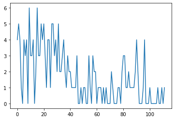

```python
#Import dataset
coal_dat = pd.read_csv("coaldisasters-ds6040.csv")
coal_dat['Count'].plot()
coal_dat.head()
```

```python
def log_like(x_data, mu, lamb, k):
    n = len(x_data)
    first_chunks = poisson.logpmf(x_data[0:k], mu)
    second_chunks = poisson.logpmf(x_data[(k):n], lamb)
    return np.sum(first_chunks) + np.sum(second_chunks)

# example call
log_like(np.random.choice(4, size=3), 1, 2, 3)
```

```
-4.386294361119891
```

```python
# example sampling from a gamma
# make sure you use the correct arguments
rate = 10
gamma.rvs(2, scale = 1/rate)
```

```
0.42837537845854384
```

```python
def samp_k(x_data, mu, lamb):
    n = len(x_data)
    possible_ks = np.arange(n)

    log_unnorm_weights = [log_like(x_data, mu, lamb, k) for k in possible_ks] #get array of loglikelihood for each possible k

    log_denominator = logsumexp(log_unnorm_weights)
    log_norm_weights = log_unnorm_weights - log_denominator

    return np.random.choice(n, size=1, p=np.exp(log_norm_weights))[0]

samp_k(coal_dat['Count'], 2, 2)
```

```
29
```

```python
class CoalDisasterModel():
    """Gibbs Sampler"""
    def __init__(self, data, a_mu, b_mu, a_lambda, b_lambda,
                 start_mu = 5, start_lambda = .1, start_k = 64, iter_num = 1000, burnin = 500):

        #Read in data and priors, and make them contained class variables
        self.data = data
        self.a_mu = a_mu
        self.b_mu = b_mu
        self.a_lambda = a_lambda
        self.b_lambda = b_lambda
        self.iter_num = iter_num
        self.burnin = burnin

        #Initalize sampling containers
        self.mu = np.zeros(iter_num+burnin+1)
        self.lambdap = np.zeros(iter_num+burnin+1)
        self.k = np.zeros(iter_num+burnin+1)

        #Put in starting values
        self.mu[0] = start_mu
        self.lambdap[0] = start_lambda
        self.k[0] = start_k

        for i in np.arange(iter_num+burnin):
            if i % 100 == 0:
                print("Iteration " + str(i))


            #This is where you modify the sampler
            self.mu[i+1] =  gamma.rvs(a_mu+sum(data[:int(self.k[i])]),scale=1/(self.k[i]+b_mu))
            self.lambdap[i+1] = gamma.rvs(a_lambda + sum(data[int(self.k[i]):]),scale=1/( len(data)- self.k[i]+b_lambda))
            self.k[i+1] = samp_k(self.data, self.mu[i+1], self.lambdap[i+1])

    def plot_posteriors(self):
        f, axs = plt.subplots(3,2, figsize = (15, 7))
        f.tight_layout(pad = 3)
        sns.kdeplot(self.mu[self.burnin:],ax =axs[0,0])
        axs[0,0].set_xlabel(r'Posterior $\mu$')
        axs[0,0].set_ylabel('Probability Density')
        sns.kdeplot(self.lambdap[self.burnin:], ax =axs[1,0])
        axs[1,0].set_xlabel(r'Posterior $\lambda$')
        axs[1,0].set_ylabel('Probability Density')
        axs[2,0].hist(self.k[self.burnin:], bins = 112)
        axs[2,0].set_xlabel(r'Posterior k')
        axs[2,0].set_ylabel('Frequency')
        axs[0,1].plot(np.arange(self.iter_num+self.burnin+1),self.mu, '-')
        axs[0,1].set_xlabel('')
        axs[0,1].set_ylabel(r'Posterior $\mu$')
        axs[1,1].plot(np.arange(self.iter_num+self.burnin+1),self.lambdap,'-')
        axs[1,1].set_xlabel('')
        axs[1,1].set_ylabel(r'Posterior $\lambda$')
        axs[2,1].plot(np.arange(self.iter_num+self.burnin+1),self.k,'-')
        axs[2,1].set_xlabel('Iteration')
        axs[2,1].set_ylabel('Posterior k')

    def get_rate_estimates(self):
        to_return =pd.DataFrame(columns = ['Posterior EAP', 'Posterior Cred Interval Lower', 'Posterior Cred Interval Upper'])
        to_return.loc[r'mu', 'Posterior EAP'] = self.mu[self.burnin:].mean()
        to_return.loc[r'lambda', 'Posterior EAP'] = self.lambdap[self.burnin:].mean()
        to_return.loc[r'mu', 'Posterior Cred Interval Lower'] = np.quantile(self.mu[self.burnin:],.025)
        to_return.loc[r'lambda', 'Posterior Cred Interval Lower'] = np.quantile(self.lambdap[self.burnin:],.025)
        to_return.loc[r'mu', 'Posterior Cred Interval Upper'] = np.quantile(self.mu[self.burnin:],.975)
        to_return.loc[r'lambda', 'Posterior Cred Interval Upper'] = np.quantile(self.lambdap[self.burnin:],.975)
        return to_return

    def get_k_probs(self):
        freq = np.bincount(abs(self.k.astype('int'))[self.burnin:])
        ii = np.nonzero(freq)[0]
        freq = np.vstack((ii,freq[ii])).T
        freq = freq.astype("float16")
        freq[:,1] = freq[:,1]/(freq[:,1].sum())
        freq = pd.DataFrame(freq, columns=['k', 'Probability of k'])

        return freq
```

```python
test = CoalDisasterModel(coal_dat['Count'], 1,1,1,1)
```

```
Iteration 0
Iteration 100
Iteration 200
Iteration 300
Iteration 400
Iteration 500
Iteration 600
Iteration 700
Iteration 800
Iteration 900
Iteration 1000
Iteration 1100
Iteration 1200
Iteration 1300
Iteration 1400
```

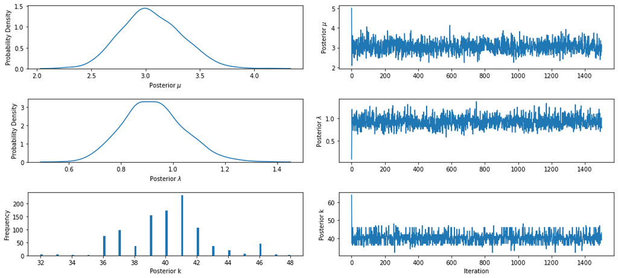

```python
test.plot_posteriors()
```

```python
test.get_rate_estimates()
```

|  | Posterior EAP | Posterior Cred Interval Lower | Posterior Cred Interval Upper |
| --- | --- | --- | --- |
| mu | 3.053165 | 2.548502 | 3.598784 |
| lambda | 0.925168 | 0.711589 | 1.172141 |

```python
most_probable = test.get_k_probs()
most_probable.sort_values(by=["Probability of k"], ascending=False).head(5)
```

|  | k | Probability of k |
| --- | --- | --- |
| 9 | 41.0 | 0.232788 |
| 8 | 40.0 | 0.172852 |
| 7 | 39.0 | 0.155884 |
| 10 | 42.0 | 0.106873 |
| 5 | 37.0 | 0.097900 |

```python
most_probable['year'] =[int(y+1851) for y in most_probable['k']]
most_probable.sort_values(by=["Probability of k"], ascending=False).head(5)
```

|  | k | Probability of k | year |
| --- | --- | --- | --- |
| 9 | 41.0 | 0.232788 | 1892 |
| 8 | 40.0 | 0.172852 | 1891 |
| 7 | 39.0 | 0.155884 | 1890 |
| 10 | 42.0 | 0.106873 | 1893 |
| 5 | 37.0 | 0.097900 | 1888 |

Then do the the following:

a) Describe your findings. What do these EAP and credible intervals imply? And what was the most likely year of the changepoint?

The year most likely to be the changepoint is 1892.

b) Why is an EAP or credible interval not neccesarily the most appropriate thing to report for the year of the changepoint?

The EAP is the expected value, and in this case, it might not be the most appropriate measure since we are interested in the overall shape of the distribution, and when things began to change.

For this reason, the credible interval is probably more appropriate, however, if we wanted a basis for a single point in time, the EAP would be better to report the year of the changepoint.

## Part 2: Bayesian Logisitic Regression with PyMC3

### 1. Load the data ansd create a new binary variable where the new quality of the wine is 0 if the wine recieved a C or an F, and a 1 if the wine recieved an A.

```python
wine = pd.read_csv('whitewine-training-ds6040.csv')
```

```python
wine['quality_binary'] = [1 if x == "A" else 0 for x in wine['wine_quality']]
```

```python
overall_best_A = "wine['wine_quality'] ~ wine['fixed.acidity']+wine['free.sulfur.dioxide']+wine['alcohol']"
```

```python
import pymc3 as pm
import pandas as pd
import numpy as np
import seaborn as sns
import matplotlib.pyplot as plt
```

```
WARNING (theano.tensor.blas): Using NumPy C-API based implementation for BLAS functions.
```

```python
###The following code is heavily based or taken directly from: https://www.kaggle.com/billbasener/pymc3-bayesian-logistic-regression-classification

def plot_traces(traces, retain=0):
    '''
    Convenience function:
    Plot traces with overlaid means and values
    '''

    ax = pm.traceplot(traces[-retain:],
                      lines=tuple([(k, {}, v['mean'])
                                   for k, v in pm.summary(traces[-retain:]).iterrows()]))

    for i, mn in enumerate(pm.summary(traces[-retain:])['mean']):
        ax[i,0].annotate('{:.2f}'.format(mn), xy=(mn,0), xycoords='data'
                    ,xytext=(5,10), textcoords='offset points', rotation=90
                    ,va='bottom', fontsize='large', color='#AA0022')
```

```python
wine.columns = wine.columns.str.replace(".", "_", regex=False)
wine_best = wine[['volatile_acidity', 'residual_sugar', 'alcohol', 'quality_binary']]
wine_best_A = wine[['fixed_acidity','free_sulfur_dioxide','alcohol', 'quality_binary']]
```

```
The glm module is deprecated and will be removed in version 4.0
We recommend to instead use Bambi https://bambinos.github.io/bambi/
Auto-assigning NUTS sampler...
Initializing NUTS using jitter+adapt_diag...
Multiprocess sampling (4 chains in 4 jobs)
NUTS: [alcohol, residual_sugar, volatile_acidity, Intercept]
```

100.00% [8000/8000 00:11<00:00 Sampling 4 chains, 0 divergences]

```
Sampling 4 chains for 1_000 tune and 1_000 draw iterations (4_000 + 4_000 draws total) took 27 seconds.
```

|  | mean | sd | hdi_3% | hdi_97% | mcse_mean | mcse_sd | ess_bulk | ess_tail | r_hat |
| --- | --- | --- | --- | --- | --- | --- | --- | --- | --- |
| Intercept | -3.938 | 0.147 | -4.218 | -3.666 | 0.003 | 0.002 | 1794.0 | 1906.0 | 1.0 |
| volatile_acidity | -0.399 | 0.129 | -0.654 | -0.167 | 0.003 | 0.002 | 2222.0 | 2524.0 | 1.0 |
| residual_sugar | 0.360 | 0.119 | 0.137 | 0.581 | 0.002 | 0.002 | 2334.0 | 2416.0 | 1.0 |
| alcohol | 1.111 | 0.122 | 0.888 | 1.346 | 0.003 | 0.002 | 1730.0 | 1658.0 | 1.0 |

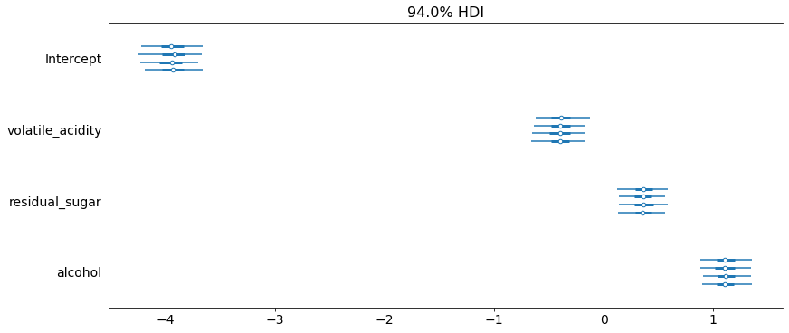

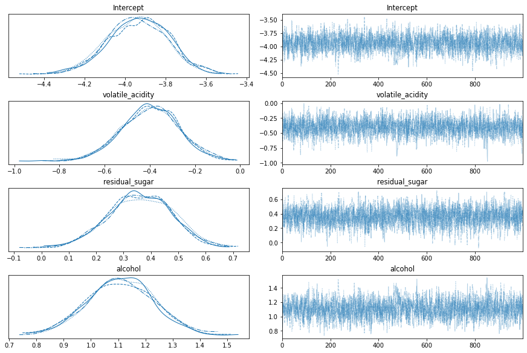

```python
#This is the general form for the logistic. You will need to change the model formula to match the white wine data.
with pm.Model() as model:
    pm.glm.GLM.from_formula(formula = "quality_binary ~ volatile_acidity + residual_sugar + alcohol",
                            data = wine_best,
                            family = pm.glm.families.Binomial())

    trace = pm.sample(1000)


#You can obtain forest plots with:
pm.plots.forestplot(trace, figsize = (12,5), rope=(0, 0))
pm.plot_trace(trace)
#You can get a table of summary statistics out using:
pm.summary(trace)
```

```
The glm module is deprecated and will be removed in version 4.0
We recommend to instead use Bambi https://bambinos.github.io/bambi/
Auto-assigning NUTS sampler...
Initializing NUTS using jitter+adapt_diag...
Multiprocess sampling (4 chains in 4 jobs)
NUTS: [alcohol, free_sulfur_dioxide, fixed_acidity, Intercept]
```

100.00% [8000/8000 00:10<00:00 Sampling 4 chains, 0 divergences]

```
Sampling 4 chains for 1_000 tune and 1_000 draw iterations (4_000 + 4_000 draws total) took 26 seconds.
```

|  | mean | sd | hdi_3% | hdi_97% | mcse_mean | mcse_sd | ess_bulk | ess_tail | r_hat |
| --- | --- | --- | --- | --- | --- | --- | --- | --- | --- |
| Intercept | -3.882 | 0.143 | -4.156 | -3.626 | 0.003 | 0.002 | 2251.0 | 2888.0 | 1.0 |
| fixed_acidity | -0.080 | 0.108 | -0.280 | 0.124 | 0.002 | 0.002 | 3143.0 | 2405.0 | 1.0 |
| free_sulfur_dioxide | 0.316 | 0.091 | 0.142 | 0.486 | 0.002 | 0.001 | 3186.0 | 2603.0 | 1.0 |
| alcohol | 0.955 | 0.111 | 0.755 | 1.172 | 0.002 | 0.002 | 2165.0 | 2563.0 | 1.0 |

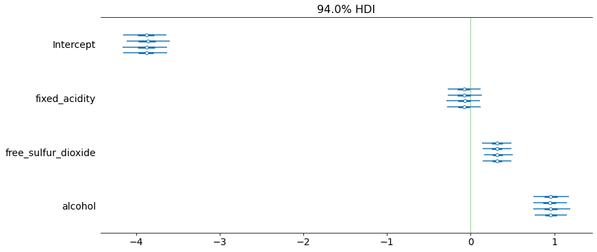

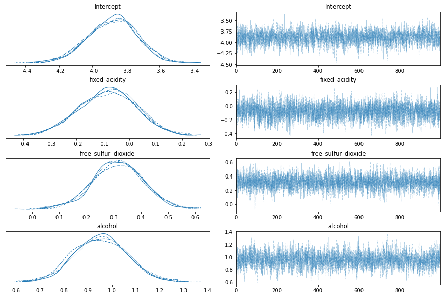

```python
#This is the general form for the logistic. You will need to change the model formula to match the white wine data.
with pm.Model() as model:
    pm.glm.GLM.from_formula(formula = "quality_binary ~ fixed_acidity + free_sulfur_dioxide + alcohol",
                            data = wine_best_A,
                            family = pm.glm.families.Binomial())

    traceA = pm.sample(1000)


#You can obtain forest plots with:
pm.plots.forestplot(traceA, figsize = (12,5), rope=(0,0))
pm.plot_trace(traceA)
#You can get a table of summary statistics out using:
pm.summary(traceA)
```

### Discuss your findings

The corresponding equations are part of the prediction model to predict whether a wine is likely to be classified as 'C' or 'F', or 'A'.

Interpreting the Intercept: The intercept for both models is close to -4. This is the 'base' quality of the wine before the other factors are considered.

The other factors increase or decrease a likelihood that a wine is rated 'A' Quality. The closer to 1, the more likely it is that a wine is rated A quality. Acid decreases this value, where alcohol increases it.

Each parameter has a range where the value is likely to truly affect the response. Fixed acidity (a-type wine) crosses 0, which means that it is uncertain if Fixed aciditity truly increases or decreases the likelihood of a wine being 'A' Quality.